# Data Science DISCOVERY Project #2 Project #2: Utkarsh Singh and Data Science [You and Data Science](https://discovery.cs.illinois.edu/guides/Course-Projects/You-and-Data-Science/)

# Section #1: The Dataset [NBA Dataset](https://www.kaggle.com/datasets/justinas/nba-players-data) </h1>

## Section 1.1: The motivation behind choosing the NBA dataset!

While exploring the various datasets on Kaggle, I thought about exploring many datasets related to my passsions and hobbies such as datasets related to `Apex Legends`, `Rocket League`, `Astronomy`, `Netflix` etc.. I ended up downloading and looking through many of these datasets however, most of them had too little data or bad quality data with a lot of blanks. Eventually, I arrived at the `NBA dataset`. This was one of my top choices to begin with since I believe there are a lot of interesting questions to be explored using NBA statistics! I am a HUGE NBA fanatic and have been following it since the last 6 years (I also went to watch a game between this fall break). Given my love for the NBA and the quality of the NBA dataset, choosing it for my project was a `no-brainer!`

[figure not shown]

## Section 1.2: Reading the dataset using pandas!

The first thing that we learned in `Data Science DISCOVERY!`. Below, I import pandas and subsequently read the NBA dataset into a dataframe called `df`.

*(The first code cell in this project!)*

```python
import pandas as pd
df = pd.read_csv("all_seasons.csv")
df
```

|  | Unnamed: 0 | player_name | team_abbreviation | age | player_height | player_weight | college | country | draft_year | draft_round | ... | pts | reb | ast | net_rating | oreb_pct | dreb_pct | usg_pct | ts_pct | ast_pct | season |
| --- | --- | --- | --- | --- | --- | --- | --- | --- | --- | --- | --- | --- | --- | --- | --- | --- | --- | --- | --- | --- | --- |
| 0 | 0 | Randy Livingston | HOU | 22.0 | 193.04 | 94.800728 | Louisiana State | USA | 1996 | 2 | ... | 3.9 | 1.5 | 2.4 | 0.3 | 0.042 | 0.071 | 0.169 | 0.487 | 0.248 | 1996-97 |
| 1 | 1 | Gaylon Nickerson | WAS | 28.0 | 190.50 | 86.182480 | Northwestern Oklahoma | USA | 1994 | 2 | ... | 3.8 | 1.3 | 0.3 | 8.9 | 0.030 | 0.111 | 0.174 | 0.497 | 0.043 | 1996-97 |
| 2 | 2 | George Lynch | VAN | 26.0 | 203.20 | 103.418976 | North Carolina | USA | 1993 | 1 | ... | 8.3 | 6.4 | 1.9 | -8.2 | 0.106 | 0.185 | 0.175 | 0.512 | 0.125 | 1996-97 |
| 3 | 3 | George McCloud | LAL | 30.0 | 203.20 | 102.058200 | Florida State | USA | 1989 | 1 | ... | 10.2 | 2.8 | 1.7 | -2.7 | 0.027 | 0.111 | 0.206 | 0.527 | 0.125 | 1996-97 |
| 4 | 4 | George Zidek | DEN | 23.0 | 213.36 | 119.748288 | UCLA | USA | 1995 | 1 | ... | 2.8 | 1.7 | 0.3 | -14.1 | 0.102 | 0.169 | 0.195 | 0.500 | 0.064 | 1996-97 |
| ... | ... | ... | ... | ... | ... | ... | ... | ... | ... | ... | ... | ... | ... | ... | ... | ... | ... | ... | ... | ... | ... |
| 12839 | 12839 | Joel Embiid | PHI | 29.0 | 213.36 | 127.005760 | Kansas | Cameroon | 2014 | 1 | ... | 33.1 | 10.2 | 4.2 | 8.8 | 0.057 | 0.243 | 0.370 | 0.655 | 0.233 | 2022-23 |
| 12840 | 12840 | John Butler Jr. | POR | 20.0 | 213.36 | 86.182480 | Florida State | USA | Undrafted | Undrafted | ... | 2.4 | 0.9 | 0.6 | -16.1 | 0.012 | 0.065 | 0.102 | 0.411 | 0.066 | 2022-23 |
| 12841 | 12841 | John Collins | ATL | 25.0 | 205.74 | 102.511792 | Wake Forest | USA | 2017 | 1 | ... | 13.1 | 6.5 | 1.2 | -0.2 | 0.035 | 0.180 | 0.168 | 0.593 | 0.052 | 2022-23 |
| 12842 | 12842 | Jericho Sims | NYK | 24.0 | 208.28 | 113.398000 | Texas | USA | 2021 | 2 | ... | 3.4 | 4.7 | 0.5 | -6.7 | 0.117 | 0.175 | 0.074 | 0.780 | 0.044 | 2022-23 |
| 12843 | 12843 | JaMychal Green | GSW | 33.0 | 205.74 | 102.965384 | Alabama | USA | Undrafted | Undrafted | ... | 6.4 | 3.6 | 0.9 | -8.2 | 0.087 | 0.164 | 0.169 | 0.650 | 0.094 | 2022-23 |

12844 rows × 22 columns

## Section 1.3: Dropping rows with blank values

After reading the dataset, I want to drop all rows which have blank values in order to make it easier to do analysis with the dataset.

```python
df = df.dropna()
df
```

|  | Unnamed: 0 | player_name | team_abbreviation | age | player_height | player_weight | college | country | draft_year | draft_round | ... | pts | reb | ast | net_rating | oreb_pct | dreb_pct | usg_pct | ts_pct | ast_pct | season |
| --- | --- | --- | --- | --- | --- | --- | --- | --- | --- | --- | --- | --- | --- | --- | --- | --- | --- | --- | --- | --- | --- |
| 0 | 0 | Randy Livingston | HOU | 22.0 | 193.04 | 94.800728 | Louisiana State | USA | 1996 | 2 | ... | 3.9 | 1.5 | 2.4 | 0.3 | 0.042 | 0.071 | 0.169 | 0.487 | 0.248 | 1996-97 |
| 1 | 1 | Gaylon Nickerson | WAS | 28.0 | 190.50 | 86.182480 | Northwestern Oklahoma | USA | 1994 | 2 | ... | 3.8 | 1.3 | 0.3 | 8.9 | 0.030 | 0.111 | 0.174 | 0.497 | 0.043 | 1996-97 |
| 2 | 2 | George Lynch | VAN | 26.0 | 203.20 | 103.418976 | North Carolina | USA | 1993 | 1 | ... | 8.3 | 6.4 | 1.9 | -8.2 | 0.106 | 0.185 | 0.175 | 0.512 | 0.125 | 1996-97 |
| 3 | 3 | George McCloud | LAL | 30.0 | 203.20 | 102.058200 | Florida State | USA | 1989 | 1 | ... | 10.2 | 2.8 | 1.7 | -2.7 | 0.027 | 0.111 | 0.206 | 0.527 | 0.125 | 1996-97 |
| 4 | 4 | George Zidek | DEN | 23.0 | 213.36 | 119.748288 | UCLA | USA | 1995 | 1 | ... | 2.8 | 1.7 | 0.3 | -14.1 | 0.102 | 0.169 | 0.195 | 0.500 | 0.064 | 1996-97 |
| ... | ... | ... | ... | ... | ... | ... | ... | ... | ... | ... | ... | ... | ... | ... | ... | ... | ... | ... | ... | ... | ... |
| 12839 | 12839 | Joel Embiid | PHI | 29.0 | 213.36 | 127.005760 | Kansas | Cameroon | 2014 | 1 | ... | 33.1 | 10.2 | 4.2 | 8.8 | 0.057 | 0.243 | 0.370 | 0.655 | 0.233 | 2022-23 |
| 12840 | 12840 | John Butler Jr. | POR | 20.0 | 213.36 | 86.182480 | Florida State | USA | Undrafted | Undrafted | ... | 2.4 | 0.9 | 0.6 | -16.1 | 0.012 | 0.065 | 0.102 | 0.411 | 0.066 | 2022-23 |
| 12841 | 12841 | John Collins | ATL | 25.0 | 205.74 | 102.511792 | Wake Forest | USA | 2017 | 1 | ... | 13.1 | 6.5 | 1.2 | -0.2 | 0.035 | 0.180 | 0.168 | 0.593 | 0.052 | 2022-23 |
| 12842 | 12842 | Jericho Sims | NYK | 24.0 | 208.28 | 113.398000 | Texas | USA | 2021 | 2 | ... | 3.4 | 4.7 | 0.5 | -6.7 | 0.117 | 0.175 | 0.074 | 0.780 | 0.044 | 2022-23 |
| 12843 | 12843 | JaMychal Green | GSW | 33.0 | 205.74 | 102.965384 | Alabama | USA | Undrafted | Undrafted | ... | 6.4 | 3.6 | 0.9 | -8.2 | 0.087 | 0.164 | 0.169 | 0.650 | 0.094 | 2022-23 |

10990 rows × 22 columns

# Section #2: EDA of the Dataset! </h1>

## Section 2.1: Narrowing down the Dataset!

Since `df` contains both **quantitative** (numerical) as well as **qualitative** (text-based) data, I will be narrowing down the dataset and making a new dataframe containing only the **relevant** numerical columns for my analysis. The reasoning behind doing this is so that I can perform exploratory data analysis with the dataset and have the flexibility to perform data analysis such as correlation, hypothesis testing, etc.. Furthermore I will be narrowing down the dataset for this section to only the `2022-23` season statistics.

In the code cell below, I define a **list** of **strings** and then I will redefine the DataFrame `df` to only include these **quantitative columns** in the following code cell.

```python
quantitative_columns = ['age','player_height','player_weight','pts','reb','ast','net_rating', 'oreb_pct', 'dreb_pct', 'usg_pct', 'ts_pct', 'ast_pct']
quantitative_columns
```

```
['age',
 'player_height',
 'player_weight',
 'pts',
 'reb',
 'ast',
 'net_rating',
 'oreb_pct',
 'dreb_pct',
 'usg_pct',
 'ts_pct',
 'ast_pct']
```

```python
df_last_season = df[(df['season']=='2022-23')]
df_last_season
```

|  | Unnamed: 0 | player_name | team_abbreviation | age | player_height | player_weight | college | country | draft_year | draft_round | ... | pts | reb | ast | net_rating | oreb_pct | dreb_pct | usg_pct | ts_pct | ast_pct | season |
| --- | --- | --- | --- | --- | --- | --- | --- | --- | --- | --- | --- | --- | --- | --- | --- | --- | --- | --- | --- | --- | --- |
| 12305 | 12305 | Quentin Grimes | NYK | 23.0 | 195.58 | 95.254320 | Houston | USA | 2021 | 1 | ... | 11.3 | 3.2 | 2.1 | 4.4 | 0.022 | 0.085 | 0.142 | 0.619 | 0.096 | 2022-23 |
| 12306 | 12306 | Quenton Jackson | WAS | 24.0 | 195.58 | 78.471416 | Texas A&M | USA | Undrafted | Undrafted | ... | 6.2 | 0.9 | 1.7 | -6.7 | 0.014 | 0.044 | 0.164 | 0.542 | 0.155 | 2022-23 |
| 12307 | 12307 | Pat Connaughton | MIL | 30.0 | 195.58 | 94.800728 | Notre Dame | USA | 2015 | 2 | ... | 7.6 | 4.6 | 1.3 | 3.4 | 0.033 | 0.144 | 0.133 | 0.531 | 0.069 | 2022-23 |
| 12308 | 12308 | RJ Barrett | NYK | 23.0 | 198.12 | 97.068688 | Duke | Canada | 2019 | 1 | ... | 19.6 | 5.0 | 2.8 | -1.2 | 0.023 | 0.121 | 0.256 | 0.531 | 0.124 | 2022-23 |
| 12309 | 12309 | Precious Achiuwa | TOR | 23.0 | 203.20 | 102.058200 | Memphis | Nigeria | 2020 | 1 | ... | 9.2 | 6.0 | 0.9 | -1.6 | 0.083 | 0.213 | 0.190 | 0.554 | 0.063 | 2022-23 |
| ... | ... | ... | ... | ... | ... | ... | ... | ... | ... | ... | ... | ... | ... | ... | ... | ... | ... | ... | ... | ... | ... |
| 12839 | 12839 | Joel Embiid | PHI | 29.0 | 213.36 | 127.005760 | Kansas | Cameroon | 2014 | 1 | ... | 33.1 | 10.2 | 4.2 | 8.8 | 0.057 | 0.243 | 0.370 | 0.655 | 0.233 | 2022-23 |
| 12840 | 12840 | John Butler Jr. | POR | 20.0 | 213.36 | 86.182480 | Florida State | USA | Undrafted | Undrafted | ... | 2.4 | 0.9 | 0.6 | -16.1 | 0.012 | 0.065 | 0.102 | 0.411 | 0.066 | 2022-23 |
| 12841 | 12841 | John Collins | ATL | 25.0 | 205.74 | 102.511792 | Wake Forest | USA | 2017 | 1 | ... | 13.1 | 6.5 | 1.2 | -0.2 | 0.035 | 0.180 | 0.168 | 0.593 | 0.052 | 2022-23 |
| 12842 | 12842 | Jericho Sims | NYK | 24.0 | 208.28 | 113.398000 | Texas | USA | 2021 | 2 | ... | 3.4 | 4.7 | 0.5 | -6.7 | 0.117 | 0.175 | 0.074 | 0.780 | 0.044 | 2022-23 |
| 12843 | 12843 | JaMychal Green | GSW | 33.0 | 205.74 | 102.965384 | Alabama | USA | Undrafted | Undrafted | ... | 6.4 | 3.6 | 0.9 | -8.2 | 0.087 | 0.164 | 0.169 | 0.650 | 0.094 | 2022-23 |

474 rows × 22 columns

```python
df_quantitative = df_last_season[quantitative_columns]
df_quantitative
```

|  | age | player_height | player_weight | pts | reb | ast | net_rating | oreb_pct | dreb_pct | usg_pct | ts_pct | ast_pct |
| --- | --- | --- | --- | --- | --- | --- | --- | --- | --- | --- | --- | --- |
| 12305 | 23.0 | 195.58 | 95.254320 | 11.3 | 3.2 | 2.1 | 4.4 | 0.022 | 0.085 | 0.142 | 0.619 | 0.096 |
| 12306 | 24.0 | 195.58 | 78.471416 | 6.2 | 0.9 | 1.7 | -6.7 | 0.014 | 0.044 | 0.164 | 0.542 | 0.155 |
| 12307 | 30.0 | 195.58 | 94.800728 | 7.6 | 4.6 | 1.3 | 3.4 | 0.033 | 0.144 | 0.133 | 0.531 | 0.069 |
| 12308 | 23.0 | 198.12 | 97.068688 | 19.6 | 5.0 | 2.8 | -1.2 | 0.023 | 0.121 | 0.256 | 0.531 | 0.124 |
| 12309 | 23.0 | 203.20 | 102.058200 | 9.2 | 6.0 | 0.9 | -1.6 | 0.083 | 0.213 | 0.190 | 0.554 | 0.063 |
| ... | ... | ... | ... | ... | ... | ... | ... | ... | ... | ... | ... | ... |
| 12839 | 29.0 | 213.36 | 127.005760 | 33.1 | 10.2 | 4.2 | 8.8 | 0.057 | 0.243 | 0.370 | 0.655 | 0.233 |
| 12840 | 20.0 | 213.36 | 86.182480 | 2.4 | 0.9 | 0.6 | -16.1 | 0.012 | 0.065 | 0.102 | 0.411 | 0.066 |
| 12841 | 25.0 | 205.74 | 102.511792 | 13.1 | 6.5 | 1.2 | -0.2 | 0.035 | 0.180 | 0.168 | 0.593 | 0.052 |
| 12842 | 24.0 | 208.28 | 113.398000 | 3.4 | 4.7 | 0.5 | -6.7 | 0.117 | 0.175 | 0.074 | 0.780 | 0.044 |
| 12843 | 33.0 | 205.74 | 102.965384 | 6.4 | 3.6 | 0.9 | -8.2 | 0.087 | 0.164 | 0.169 | 0.650 | 0.094 |

474 rows × 12 columns

## Section 2.2: Exploring some statistics!

```python
df_quantitative.describe()
```

|  | age | player_height | player_weight | pts | reb | ast | net_rating | oreb_pct | dreb_pct | usg_pct | ts_pct | ast_pct |
| --- | --- | --- | --- | --- | --- | --- | --- | --- | --- | --- | --- | --- |
| count | 474.000000 | 474.000000 | 474.000000 | 474.000000 | 474.000000 | 474.000000 | 474.000000 | 474.000000 | 474.000000 | 474.000000 | 474.000000 | 474.000000 |
| mean | 26.143460 | 198.757679 | 97.504098 | 9.125738 | 3.477426 | 2.051055 | -1.364346 | 0.044536 | 0.130808 | 0.178973 | 0.564074 | 0.135432 |
| std | 4.226226 | 7.976911 | 10.672747 | 6.718906 | 2.208330 | 1.909188 | 12.175891 | 0.035317 | 0.055992 | 0.055712 | 0.100740 | 0.085720 |
| min | 19.000000 | 175.260000 | 72.574720 | 0.000000 | 0.000000 | 0.000000 | -94.700000 | 0.000000 | 0.000000 | 0.052000 | 0.000000 | 0.000000 |
| 25% | 23.000000 | 193.040000 | 90.718400 | 4.200000 | 1.800000 | 0.800000 | -5.900000 | 0.019000 | 0.094000 | 0.139000 | 0.525250 | 0.073000 |
| 50% | 25.000000 | 198.120000 | 97.522280 | 7.200000 | 3.000000 | 1.400000 | -0.550000 | 0.034000 | 0.119000 | 0.172000 | 0.568000 | 0.109000 |
| 75% | 29.000000 | 203.200000 | 104.326160 | 12.075000 | 4.500000 | 2.700000 | 3.575000 | 0.060000 | 0.159000 | 0.206750 | 0.610000 | 0.183750 |
| max | 43.000000 | 218.440000 | 128.820128 | 33.100000 | 12.500000 | 10.700000 | 95.000000 | 0.250000 | 0.400000 | 0.500000 | 1.064000 | 0.457000 |

From the above table, we have obtained a lot of interesting values. A surprising value in this matrix is the mean height and weight of an NBA player. The average NBA player is nearly 200cm (~6'7!) tall and weighs around 100kgs!. Furthermore, we can note that the average points, rebounds and assists of NBA players last season was around 9.13 points, 3.48 rebounds and 2.05 assists.

## Section 2.3: Who are the best players?

Now that we have found some of the average stats of NBA players, I would like to find the top scorers, playmakers and rebounders in the NBA all time as well as during the last season. Furthermore, since many players have multiple seasons in the dataset, I will be finding their average performances for the all-time statistics. The following code cell groups the players by name and finds their average statistics.

```python
name_column = ['player_name','pts','reb','ast','net_rating', 'oreb_pct', 'dreb_pct', 'usg_pct', 'ts_pct', 'ast_pct']
```

```python
#All-time dataframe
df1 = df[name_column]
df_name_all_time = df1.groupby("player_name").agg("mean").reset_index()
df_name_all_time
```

|  | player_name | pts | reb | ast | net_rating | oreb_pct | dreb_pct | usg_pct | ts_pct | ast_pct |
| --- | --- | --- | --- | --- | --- | --- | --- | --- | --- | --- |
| 0 | A.C. Green | 5.780000 | 6.060000 | 0.860000 | -1.880000 | 0.093000 | 0.1864 | 0.127400 | 0.4868 | 0.054000 |
| 1 | A.J. Bramlett | 1.000000 | 2.800000 | 0.000000 | -32.600000 | 0.158000 | 0.2080 | 0.146000 | 0.1900 | 0.000000 |
| 2 | A.J. Guyton | 3.800000 | 0.700000 | 1.566667 | -6.700000 | 0.013333 | 0.0400 | 0.224000 | 0.3240 | 0.282000 |
| 3 | A.J. Lawson | 3.700000 | 1.400000 | 0.100000 | -20.100000 | 0.046000 | 0.1520 | 0.189000 | 0.5890 | 0.032000 |
| 4 | AJ Green | 4.400000 | 1.300000 | 0.600000 | -4.900000 | 0.016000 | 0.1050 | 0.159000 | 0.6070 | 0.092000 |
| ... | ... | ... | ... | ... | ... | ... | ... | ... | ... | ... |
| 2215 | Zendon Hamilton | 3.366667 | 2.566667 | 0.166667 | -11.866667 | 0.115833 | 0.2525 | 0.232667 | 0.5095 | 0.023500 |
| 2216 | Zhaire Smith | 3.900000 | 1.250000 | 1.000000 | -2.500000 | 0.014000 | 0.0835 | 0.165500 | 0.4230 | 0.092000 |
| 2217 | Ziaire Williams | 6.900000 | 2.100000 | 0.950000 | -0.500000 | 0.022500 | 0.0880 | 0.161000 | 0.5350 | 0.074000 |
| 2218 | Zion Williamson | 25.166667 | 6.833333 | 3.466667 | 5.000000 | 0.077667 | 0.1310 | 0.288667 | 0.6390 | 0.179333 |
| 2219 | Zylan Cheatham | 1.500000 | 1.150000 | 0.400000 | -65.350000 | 0.031000 | 0.0640 | 0.176500 | 0.3335 | 0.047000 |

2220 rows × 10 columns

```python
#All-time top scorers
df_top_scorers = df_name_all_time.nlargest(3,'pts')
df_top_scorers
```

|  | player_name | pts | reb | ast | net_rating | oreb_pct | dreb_pct | usg_pct | ts_pct | ast_pct |
| --- | --- | --- | --- | --- | --- | --- | --- | --- | --- | --- |
| 1276 | Kevin Durant | 27.233333 | 7.073333 | 4.433333 | 6.380000 | 0.020533 | 0.177933 | 0.298133 | 0.623333 | 0.204200 |
| 1103 | Joel Embiid | 26.542857 | 10.928571 | 3.314286 | 8.057143 | 0.077000 | 0.263286 | 0.347429 | 0.606714 | 0.192000 |
| 58 | Allen Iverson | 26.064286 | 3.692857 | 6.000000 | 0.600000 | 0.022214 | 0.080571 | 0.311000 | 0.517000 | 0.274643 |

```python
#All-time top playmakers
df_top_playmakers = df_name_all_time.nlargest(3,'ast')
df_top_playmakers
```

|  | player_name | pts | reb | ast | net_rating | oreb_pct | dreb_pct | usg_pct | ts_pct | ast_pct |
| --- | --- | --- | --- | --- | --- | --- | --- | --- | --- | --- |
| 355 | Chris Paul | 17.844444 | 4.494444 | 9.450000 | 7.122222 | 0.019722 | 0.124611 | 0.231056 | 0.581611 | 0.427778 |
| 2063 | Trae Young | 25.720000 | 3.720000 | 9.340000 | -0.480000 | 0.019200 | 0.086800 | 0.316400 | 0.579800 | 0.419000 |
| 997 | Jason Kidd | 12.376471 | 6.241176 | 8.682353 | 4.482353 | 0.035765 | 0.161647 | 0.183824 | 0.515294 | 0.369765 |

```python
#All-time top rebounders
df_top_rebounders = df_name_all_time.nlargest(3,'reb')
df_top_rebounders
```

|  | player_name | pts | reb | ast | net_rating | oreb_pct | dreb_pct | usg_pct | ts_pct | ast_pct |
| --- | --- | --- | --- | --- | --- | --- | --- | --- | --- | --- |
| 534 | Dennis Rodman | 3.825000 | 14.150000 | 2.125000 | 3.575000 | 0.151250 | 0.335250 | 0.079250 | 0.445750 | 0.083500 |
| 1026 | Jayson Williams | 11.466667 | 13.033333 | 1.100000 | -3.733333 | 0.173333 | 0.239000 | 0.166667 | 0.486000 | 0.053667 |
| 76 | Andre Drummond | 13.072727 | 12.509091 | 1.354545 | -1.318182 | 0.153091 | 0.321182 | 0.213818 | 0.550909 | 0.077455 |

```python
#Last season dataframe
df2 = df_last_season[name_column]
df_name_last_season = df2.groupby("player_name").agg("mean").reset_index()
df_name_last_season
```

|  | player_name | pts | reb | ast | net_rating | oreb_pct | dreb_pct | usg_pct | ts_pct | ast_pct |
| --- | --- | --- | --- | --- | --- | --- | --- | --- | --- | --- |
| 0 | A.J. Lawson | 3.7 | 1.4 | 0.1 | -20.1 | 0.046 | 0.152 | 0.189 | 0.589 | 0.032 |
| 1 | AJ Green | 4.4 | 1.3 | 0.6 | -4.9 | 0.016 | 0.105 | 0.159 | 0.607 | 0.092 |
| 2 | AJ Griffin | 8.9 | 2.1 | 1.0 | 1.5 | 0.026 | 0.080 | 0.174 | 0.577 | 0.070 |
| 3 | Aaron Gordon | 16.3 | 6.6 | 3.0 | 12.1 | 0.086 | 0.136 | 0.206 | 0.617 | 0.129 |
| 4 | Aaron Holiday | 3.9 | 1.2 | 1.4 | 0.9 | 0.028 | 0.059 | 0.129 | 0.528 | 0.135 |
| ... | ... | ... | ... | ... | ... | ... | ... | ... | ... | ... |
| 469 | Zach Collins | 11.6 | 6.4 | 2.9 | -7.5 | 0.076 | 0.190 | 0.209 | 0.599 | 0.180 |
| 470 | Zach LaVine | 24.8 | 4.5 | 4.2 | 0.3 | 0.016 | 0.108 | 0.278 | 0.607 | 0.187 |
| 471 | Zeke Nnaji | 5.2 | 2.6 | 0.3 | -5.9 | 0.087 | 0.099 | 0.149 | 0.620 | 0.040 |
| 472 | Ziaire Williams | 5.7 | 2.1 | 0.9 | -5.2 | 0.028 | 0.105 | 0.178 | 0.511 | 0.086 |
| 473 | Zion Williamson | 26.0 | 7.0 | 4.6 | 7.8 | 0.060 | 0.148 | 0.288 | 0.652 | 0.231 |

474 rows × 10 columns

```python
#All-time top scorers
df_top_scorers = df_name_last_season.nlargest(3,'pts')
df_top_scorers
```

|  | player_name | pts | reb | ast | net_rating | oreb_pct | dreb_pct | usg_pct | ts_pct | ast_pct |
| --- | --- | --- | --- | --- | --- | --- | --- | --- | --- | --- |
| 221 | Joel Embiid | 33.1 | 10.2 | 4.2 | 8.8 | 0.057 | 0.243 | 0.370 | 0.655 | 0.233 |
| 80 | Damian Lillard | 32.2 | 4.8 | 7.3 | 2.1 | 0.022 | 0.112 | 0.331 | 0.645 | 0.338 |
| 405 | Shai Gilgeous-Alexander | 31.4 | 4.8 | 5.5 | 2.7 | 0.023 | 0.109 | 0.318 | 0.626 | 0.249 |

```python
#All-time top playmakers
df_top_playmakers = df_name_last_season.nlargest(3,'ast')
df_top_playmakers
```

|  | player_name | pts | reb | ast | net_rating | oreb_pct | dreb_pct | usg_pct | ts_pct | ast_pct |
| --- | --- | --- | --- | --- | --- | --- | --- | --- | --- | --- |
| 190 | James Harden | 21.0 | 6.1 | 10.7 | 6.1 | 0.021 | 0.151 | 0.247 | 0.607 | 0.439 |
| 449 | Tyrese Haliburton | 20.7 | 3.7 | 10.4 | -1.0 | 0.018 | 0.092 | 0.238 | 0.624 | 0.457 |
| 434 | Trae Young | 26.2 | 3.0 | 10.2 | 1.3 | 0.021 | 0.062 | 0.313 | 0.573 | 0.414 |

```python
#All-time top rebounders
df_top_rebounders = df_name_last_season.nlargest(3,'reb')
df_top_rebounders
```

|  | player_name | pts | reb | ast | net_rating | oreb_pct | dreb_pct | usg_pct | ts_pct | ast_pct |
| --- | --- | --- | --- | --- | --- | --- | --- | --- | --- | --- |
| 19 | Anthony Davis | 25.9 | 12.5 | 2.6 | 4.8 | 0.102 | 0.248 | 0.277 | 0.627 | 0.128 |
| 114 | Domantas Sabonis | 19.1 | 12.3 | 7.3 | 3.9 | 0.096 | 0.275 | 0.213 | 0.668 | 0.297 |
| 414 | Steven Adams | 8.6 | 11.5 | 2.3 | 9.7 | 0.171 | 0.222 | 0.139 | 0.564 | 0.107 |

# Section #3: EDV of the Dataset! </h1>

## Section 3.1: How has the game evolved over the last two decades?

```python
season_stats=['season','pts','reb','ast','net_rating', 'oreb_pct', 'dreb_pct', 'usg_pct', 'ts_pct', 'ast_pct']
df_season = df[season_stats]
df4 = df_season.groupby('season').agg('sum').reset_index()
df4
```

|  | season | pts | reb | ast | net_rating | oreb_pct | dreb_pct | usg_pct | ts_pct | ast_pct |
| --- | --- | --- | --- | --- | --- | --- | --- | --- | --- | --- |
| 0 | 1996-97 | 3407.7 | 1499.1 | 779.1 | -970.1 | 27.112 | 57.830 | 78.756 | 214.312 | 56.736 |
| 1 | 1997-98 | 3367.2 | 1477.0 | 776.2 | -1002.3 | 27.156 | 56.096 | 80.506 | 211.176 | 57.792 |
| 2 | 1998-99 | 3069.3 | 1416.6 | 696.2 | -822.2 | 26.501 | 54.609 | 79.131 | 201.974 | 55.775 |
| 3 | 1999-00 | 3314.5 | 1511.0 | 778.1 | -953.0 | 24.845 | 58.295 | 76.596 | 206.216 | 56.629 |
| 4 | 2000-01 | 3184.9 | 1467.4 | 765.3 | -893.1 | 24.150 | 56.978 | 75.333 | 201.091 | 57.173 |
| 5 | 2001-02 | 3151.1 | 1424.2 | 752.0 | -1095.1 | 23.434 | 55.039 | 74.576 | 197.241 | 57.708 |
| 6 | 2002-03 | 2881.1 | 1317.4 | 684.0 | -539.6 | 23.031 | 51.186 | 69.121 | 181.705 | 52.926 |
| 7 | 2003-04 | 2856.0 | 1329.7 | 674.1 | -939.3 | 22.536 | 52.175 | 69.583 | 185.276 | 51.033 |
| 8 | 2004-05 | 3038.2 | 1353.1 | 694.4 | -937.5 | 23.384 | 53.539 | 70.665 | 194.031 | 51.251 |
| 9 | 2005-06 | 2899.6 | 1253.6 | 642.0 | -779.2 | 21.030 | 53.121 | 67.180 | 188.589 | 46.911 |
| 10 | 2006-07 | 2921.7 | 1235.6 | 665.5 | -912.9 | 21.704 | 52.709 | 68.282 | 189.434 | 48.331 |
| 11 | 2007-08 | 2873.4 | 1230.1 | 665.0 | -736.7 | 20.370 | 51.499 | 67.373 | 186.996 | 47.416 |
| 12 | 2008-09 | 2947.4 | 1241.9 | 637.9 | -828.1 | 21.350 | 51.340 | 67.335 | 187.624 | 44.667 |
| 13 | 2009-10 | 2938.2 | 1241.8 | 640.6 | -754.3 | 19.925 | 50.511 | 65.394 | 184.935 | 44.784 |
| 14 | 2010-11 | 2844.4 | 1219.0 | 640.6 | -930.5 | 19.397 | 51.398 | 65.986 | 186.138 | 46.896 |
| 15 | 2011-12 | 2976.5 | 1304.2 | 674.3 | -874.7 | 21.536 | 54.974 | 72.614 | 196.185 | 51.080 |
| 16 | 2012-13 | 2959.5 | 1280.0 | 672.6 | -1097.1 | 20.620 | 53.176 | 71.833 | 191.493 | 50.434 |
| 17 | 2013-14 | 3168.3 | 1335.8 | 701.1 | -779.9 | 20.790 | 56.536 | 72.876 | 201.439 | 51.310 |
| 18 | 2014-15 | 3238.4 | 1377.5 | 732.9 | -1165.8 | 20.021 | 57.274 | 75.860 | 206.462 | 54.920 |
| 19 | 2015-16 | 3253.1 | 1367.2 | 710.1 | -1159.9 | 18.845 | 57.702 | 72.826 | 202.989 | 51.330 |
| 20 | 2016-17 | 3339.7 | 1360.0 | 718.7 | -948.6 | 19.072 | 58.964 | 73.817 | 205.587 | 52.233 |
| 21 | 2017-18 | 3596.6 | 1453.7 | 801.2 | -1117.7 | 17.028 | 58.315 | 78.865 | 232.715 | 56.787 |
| 22 | 2018-19 | 3716.0 | 1503.5 | 821.0 | -881.5 | 16.603 | 55.236 | 75.712 | 220.319 | 56.459 |
| 23 | 2019-20 | 3942.4 | 1593.7 | 866.9 | -479.3 | 18.534 | 60.655 | 81.499 | 242.991 | 61.159 |
| 24 | 2020-21 | 4187.9 | 1644.8 | 918.7 | -958.2 | 18.363 | 61.304 | 82.967 | 253.315 | 61.148 |
| 25 | 2021-22 | 4336.0 | 1780.4 | 975.2 | -2167.3 | 23.218 | 68.112 | 92.235 | 277.325 | 69.778 |
| 26 | 2022-23 | 4325.6 | 1648.3 | 972.2 | -646.7 | 21.110 | 62.003 | 84.833 | 267.371 | 64.195 |

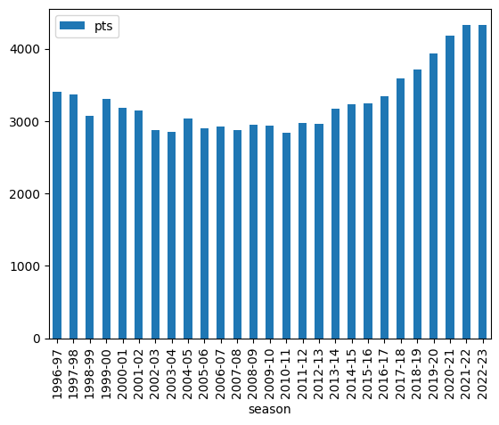

```python
df4.plot.bar(x='season',y='pts')
```

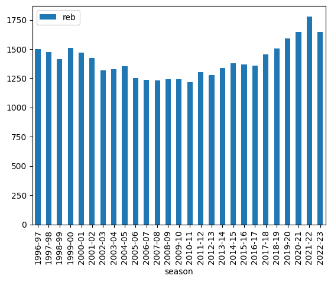

```python
df4.plot.bar(x='season',y='reb')
```

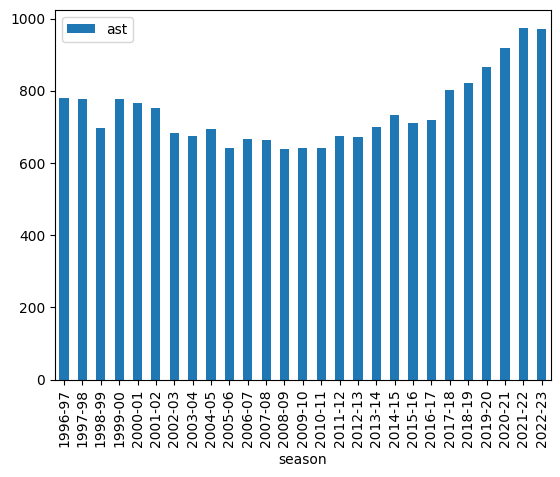

```python
df4.plot.bar(x='season',y='ast')
```

## Section 3.2: My analysis and explanation of the data

From the data, we can observe that there is the same general trend in all 3 of these statistics. The number of points, assists and rebounds seem to have gone down during between 2000-2010 and increased again from 2010-2023 with the last 2 seasons having the highest number in all 3 statistics. I predict that this trend will continue and the total points scored will continue to increase as time goes on. I make this prediction that this is happening since the game is continuing to change every decade. Last decade, the players played a slower-paced and more defense oriented version of basketball meanwhile this decade, with the huge influence that 3 pointers have had on basketball, the game has become more dynamic and fast-paced than ever before .

# Section #4:Data Analysis of the Dataset! </h1>

## Section 4.1: Is the first to get drafted the best?

In the NBA, there is a common stereotype that the number one draft pick of a year will always have the best rookie season. In today's basketball talks, `Victor Wembenyama`, this year's number 1 pick, is a very hot topic and everyone believes that he will go on to win the best rookie award. However, I wanted to justify this stereotype myself using the NBA dataset. This got me interested in the `correlation` between the `draft number` of a player and their `points` scored. This is becuase the number of points per game scored is often used as a measure to see how a player is performing. While this may not be comprehensive of the full picture, it provides a good enough picture. In the following code cell, I narrow down the data to the columns that I need.

```python
relevant_columns = ['pts','draft_number']
```

Since I am checking the performance of the players drafted in a specific year during their rookie season, it is necessary to use a complex conditional in order to narrow down to a specific year and season. Ideally, I would perform regression on every year and season in the dataset however in this project, I will only perform it for the most recent year. I run the code to find the complex conditional in the following code cell.

```python
df_2 = df[(df['draft_year']=='2022')&(df['season']=='2022-23')]
df_relevant = df_2[relevant_columns]
```

In the following code cell, I had to use the command `astype()`. This is because the dtype of my column `draft_number` was initially set to be `object`. Due to this, I was unable to use this column as an integer as it is supposed to be used. Therefore, I did some research and found a command in order to change the dtype of this column.

```python
df_relevant['draft_number']=df_relevant['draft_number'].astype('float64')
df_relevant
```

|  | pts | draft_number |
| --- | --- | --- |
| 12312 | 3.3 | 30.0 |
| 12319 | 3.9 | 28.0 |
| 12326 | 20.0 | 1.0 |
| 12329 | 1.9 | 44.0 |
| 12351 | 2.7 | 43.0 |
| 12374 | 7.9 | 14.0 |
| 12394 | 1.3 | 51.0 |
| 12398 | 4.7 | 29.0 |
| 12403 | 1.0 | 42.0 |
| 12407 | 2.0 | 47.0 |
| 12423 | 1.4 | 26.0 |
| 12425 | 9.2 | 22.0 |
| 12443 | 9.9 | 7.0 |
| 12450 | 9.3 | 17.0 |
| 12502 | 6.7 | 23.0 |
| 12572 | 16.7 | 6.0 |
| 12575 | 5.0 | 25.0 |
| 12590 | 8.9 | 16.0 |
| 12607 | 9.5 | 31.0 |
| 12613 | 4.7 | 21.0 |
| 12614 | 3.1 | 33.0 |
| 12629 | 2.2 | 18.0 |
| 12637 | 5.3 | 40.0 |
| 12643 | 3.8 | 32.0 |
| 12657 | 2.6 | 49.0 |
| 12681 | 2.2 | 38.0 |
| 12693 | 12.2 | 4.0 |
| 12699 | 1.5 | 48.0 |
| 12709 | 9.0 | 15.0 |
| 12718 | 3.1 | 35.0 |
| 12747 | 10.2 | 20.0 |
| 12755 | 14.1 | 12.0 |
| 12773 | 9.1 | 13.0 |
| 12779 | 1.6 | 53.0 |
| 12783 | 12.8 | 3.0 |
| 12785 | 3.9 | 57.0 |
| 12788 | 16.3 | 5.0 |
| 12793 | 3.0 | 19.0 |
| 12814 | 3.1 | 45.0 |
| 12819 | 5.8 | 10.0 |
| 12824 | 5.9 | 34.0 |
| 12832 | 11.0 | 9.0 |

In the following code cell, I checked the actual correlation between the points and draft number of a player drafted in 2022 and found that it is as expected, a high negative correlation between the two. This makes the data suitable for performing regression.

```python
df_relevant.corr()
```

|  | pts | draft_number |
| --- | --- | --- |
| pts | 1.000000 | -0.797048 |
| draft_number | -0.797048 | 1.000000 |

## Section 4.2: Visualization of the data

Next, I plotted a scatter graph for to better demonstrate the correlation between these variables visually and to understand how the points scored vary as the draft number increases. We find that the trend is just as expected with the points scored decreasing on average as draft number increases.

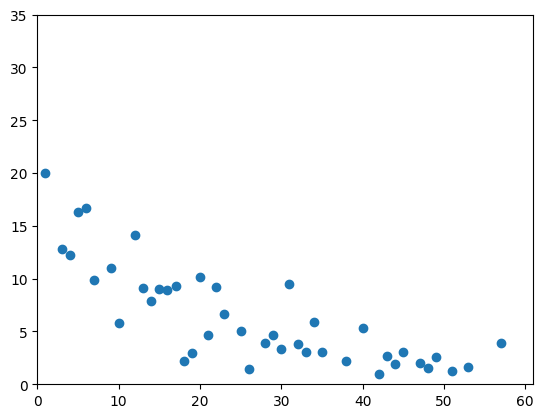

```python
import matplotlib.pyplot as plt
plt.scatter(df_relevant['draft_number'],df_relevant['pts'])
plt.xlim(0, 61)
plt.ylim(0, 35)
plt.show()
```

## Section 4.3: Finding the regression line

The next step was calculating the **slope** using the formula:

> $$\text{slope} = r * \frac{SD(y)}{SD(x)}$$

Where $r$ is the correlation coefficient between $X$ and $y$, and $SD$ stands for standard deviation.

```python
slope = df_relevant.corr()['pts']['draft_number']*(df_relevant['pts'].std()/df_relevant['draft_number'].std())
slope
```

```
-0.24324849084752856
```

Then I calculated the **y-intercept** of the regression line using the formula as follows:

> $$\text{intercept} = \text{avg}(y) - \text{slope} * \text{avg}(X)$$

```python
intercept = df_relevant['pts'].mean() - slope *df_relevant['draft_number'].mean()
intercept
```

```
12.929096840357008
```

## Section 4.4: What does the regression line look like?

Now that I have found the equation to the regression line, lets see how it would look on the scattergraph as a best fit. In the following cell, I imported the `seaborn` library in order to visualize the regression line that I derived in the last two steps.

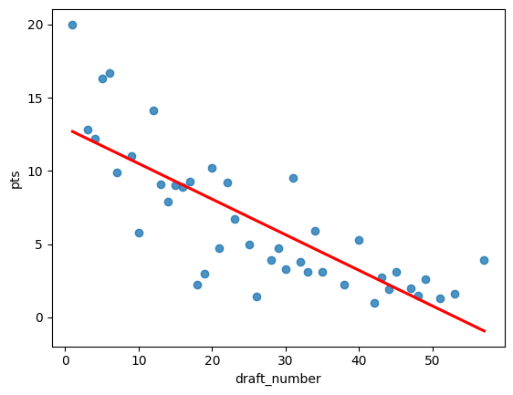

```python
import seaborn as sns

sns.regplot(data=df_relevant, x="draft_number", y="pts", ci=None, line_kws={'color':'red'})
```

## Section 4.5: Prediction and residual

Using the regression model that we have generated, I will create two additional columns in the dataframe, the prediction column and the residual. The residual will give us a measure of how close the prediction is to the actual value.

```python
df_relevant['pts_prediction'] = slope*df_relevant['draft_number']+intercept
df_relevant
```

|  | pts | draft_number | pts_prediction |
| --- | --- | --- | --- |
| 12312 | 3.3 | 30.0 | 5.631642 |
| 12319 | 3.9 | 28.0 | 6.118139 |
| 12326 | 20.0 | 1.0 | 12.685848 |
| 12329 | 1.9 | 44.0 | 2.226163 |
| 12351 | 2.7 | 43.0 | 2.469412 |
| 12374 | 7.9 | 14.0 | 9.523618 |
| 12394 | 1.3 | 51.0 | 0.523424 |
| 12398 | 4.7 | 29.0 | 5.874891 |
| 12403 | 1.0 | 42.0 | 2.712660 |
| 12407 | 2.0 | 47.0 | 1.496418 |
| 12423 | 1.4 | 26.0 | 6.604636 |
| 12425 | 9.2 | 22.0 | 7.577630 |
| 12443 | 9.9 | 7.0 | 11.226357 |
| 12450 | 9.3 | 17.0 | 8.793872 |
| 12502 | 6.7 | 23.0 | 7.334382 |
| 12572 | 16.7 | 6.0 | 11.469606 |
| 12575 | 5.0 | 25.0 | 6.847885 |
| 12590 | 8.9 | 16.0 | 9.037121 |
| 12607 | 9.5 | 31.0 | 5.388394 |
| 12613 | 4.7 | 21.0 | 7.820879 |
| 12614 | 3.1 | 33.0 | 4.901897 |
| 12629 | 2.2 | 18.0 | 8.550624 |
| 12637 | 5.3 | 40.0 | 3.199157 |
| 12643 | 3.8 | 32.0 | 5.145145 |
| 12657 | 2.6 | 49.0 | 1.009921 |
| 12681 | 2.2 | 38.0 | 3.685654 |
| 12693 | 12.2 | 4.0 | 11.956103 |
| 12699 | 1.5 | 48.0 | 1.253169 |
| 12709 | 9.0 | 15.0 | 9.280369 |
| 12718 | 3.1 | 35.0 | 4.415400 |
| 12747 | 10.2 | 20.0 | 8.064127 |
| 12755 | 14.1 | 12.0 | 10.010115 |
| 12773 | 9.1 | 13.0 | 9.766866 |
| 12779 | 1.6 | 53.0 | 0.036927 |
| 12783 | 12.8 | 3.0 | 12.199351 |
| 12785 | 3.9 | 57.0 | -0.936067 |
| 12788 | 16.3 | 5.0 | 11.712854 |
| 12793 | 3.0 | 19.0 | 8.307376 |
| 12814 | 3.1 | 45.0 | 1.982915 |
| 12819 | 5.8 | 10.0 | 10.496612 |
| 12824 | 5.9 | 34.0 | 4.658648 |
| 12832 | 11.0 | 9.0 | 10.739860 |

```python
df_relevant['residual'] = df_relevant['pts']-df_relevant['pts_prediction']
df_relevant
```

|  | pts | draft_number | pts_prediction | residual |
| --- | --- | --- | --- | --- |
| 12312 | 3.3 | 30.0 | 5.631642 | -2.331642 |
| 12319 | 3.9 | 28.0 | 6.118139 | -2.218139 |
| 12326 | 20.0 | 1.0 | 12.685848 | 7.314152 |
| 12329 | 1.9 | 44.0 | 2.226163 | -0.326163 |
| 12351 | 2.7 | 43.0 | 2.469412 | 0.230588 |
| 12374 | 7.9 | 14.0 | 9.523618 | -1.623618 |
| 12394 | 1.3 | 51.0 | 0.523424 | 0.776576 |
| 12398 | 4.7 | 29.0 | 5.874891 | -1.174891 |
| 12403 | 1.0 | 42.0 | 2.712660 | -1.712660 |
| 12407 | 2.0 | 47.0 | 1.496418 | 0.503582 |
| 12423 | 1.4 | 26.0 | 6.604636 | -5.204636 |
| 12425 | 9.2 | 22.0 | 7.577630 | 1.622370 |
| 12443 | 9.9 | 7.0 | 11.226357 | -1.326357 |
| 12450 | 9.3 | 17.0 | 8.793872 | 0.506128 |
| 12502 | 6.7 | 23.0 | 7.334382 | -0.634382 |
| 12572 | 16.7 | 6.0 | 11.469606 | 5.230394 |
| 12575 | 5.0 | 25.0 | 6.847885 | -1.847885 |
| 12590 | 8.9 | 16.0 | 9.037121 | -0.137121 |
| 12607 | 9.5 | 31.0 | 5.388394 | 4.111606 |
| 12613 | 4.7 | 21.0 | 7.820879 | -3.120879 |
| 12614 | 3.1 | 33.0 | 4.901897 | -1.801897 |
| 12629 | 2.2 | 18.0 | 8.550624 | -6.350624 |
| 12637 | 5.3 | 40.0 | 3.199157 | 2.100843 |
| 12643 | 3.8 | 32.0 | 5.145145 | -1.345145 |
| 12657 | 2.6 | 49.0 | 1.009921 | 1.590079 |
| 12681 | 2.2 | 38.0 | 3.685654 | -1.485654 |
| 12693 | 12.2 | 4.0 | 11.956103 | 0.243897 |
| 12699 | 1.5 | 48.0 | 1.253169 | 0.246831 |
| 12709 | 9.0 | 15.0 | 9.280369 | -0.280369 |
| 12718 | 3.1 | 35.0 | 4.415400 | -1.315400 |
| 12747 | 10.2 | 20.0 | 8.064127 | 2.135873 |
| 12755 | 14.1 | 12.0 | 10.010115 | 4.089885 |
| 12773 | 9.1 | 13.0 | 9.766866 | -0.666866 |
| 12779 | 1.6 | 53.0 | 0.036927 | 1.563073 |
| 12783 | 12.8 | 3.0 | 12.199351 | 0.600649 |
| 12785 | 3.9 | 57.0 | -0.936067 | 4.836067 |
| 12788 | 16.3 | 5.0 | 11.712854 | 4.587146 |
| 12793 | 3.0 | 19.0 | 8.307376 | -5.307376 |
| 12814 | 3.1 | 45.0 | 1.982915 | 1.117085 |
| 12819 | 5.8 | 10.0 | 10.496612 | -4.696612 |
| 12824 | 5.9 | 34.0 | 4.658648 | 1.241352 |
| 12832 | 11.0 | 9.0 | 10.739860 | 0.260140 |

# Section #5:Overall Summary </h1>

From the results of the previous section, we have confirmed that there is an evident trend in the performance of a player, as measured by points scored in correlation to their draft number. In specific, there is a negative linear correation between these variables i.e, as the draft number number increases, the points scored by the player decreases.